[output not shown]

[output not shown]

# Intro to SAS Macros

Leah Durbak

[figure not shown]

## Overview

1. Explain what the SAS macro facility is, why you want to employ it, and how it works
2. Walk through examples of using macro in SAS code
3. List tips/tricks/common stumbling blocks for using SAS macros
4. List resources where you can learn more

# What is the SAS Macro Facility?

## Text processing facility used for

- symbolic substitution

```sas
proc print data=sashelp.baseball (obs=10);
    var Name;
    where nAtBat > 600;
    title "Players with at Bats over 600";
    title "Created 10:24 Monday, 17JUL2019";
run;
```

```
                      Created 10:24 Monday, 17JUL2019

                           Obs    Name

                            25    Buckner, Bill
                            60    Ripken, Cal
                            83    Mattingly, Don
                            85    Murphy, Dale
                            87    Parker, Dave
                           109    Bell, George
                           142    Carter, Joe
                           160    Presley, Jim
                           164    Rice, Jim
                           188    Puckett, Kirby
```

## Text processing facility used for

- symbolic substitution
- automated production

```sas
proc freq data=sashelp.baseball;
    title "Positions of Players with at Bats over 600";
    table Position;
    where nAtBat > 600;
run;
proc means data=sashelp.baseball;
    title "Home Run N Distributions for Players with at Bats over 600 by League";
    where nAtBat > 600;
    class League;
    var nHome;
run;
```

```
                Positions of Players with at Bats over 600

                            The FREQ Procedure

                            Position(s) in 1986

                                            Cumulative    Cumulative
       Position    Frequency     Percent     Frequency      Percent
       -------------------------------------------------------------
       1B                 3       16.67             3        16.67
       2B                 3       16.67             6        33.33
       3B                 1        5.56             7        38.89
       CF                 4       22.22            11        61.11
       LF                 2       11.11            13        72.22
       RF                 3       16.67            16        88.89
       SS                 2       11.11            18       100.00



   Home Run N Distributions for Players with at Bats over 600 by League

                            The MEANS Procedure

               Analysis Variable : nHome Home Runs in 1986

League
at the
End of      N
1986      Obs    N          Mean       Std Dev       Minimum       Maximum
--------------------------------------------------------------------------
American   12   12    21.9166667     9.6243851     4.0000000    31.0000000

National    6    6    18.8333333     9.6211572     6.0000000    31.0000000
--------------------------------------------------------------------------
```

## Text processing facility used for

- symbolic substitution
- automated production
- conditional construction

```
Is it Friday?
If no, run this report:
  proc print data=sashelp.baseball (obs=10);
  run;
If yes, run this report:
  proc means data=sashelp.baseball (obs=10);
  run;
```

## Text processing facility used for

- symbolic substitution
- automated production
- conditional construction
- dynamic generation of code

```
proc print data=dat.yearly_summary_2015;
run;
proc print data=dat.yearly_summary_2016;
run;
proc print data=dat.yearly_summary_2017;
run;
```

# Why use macros?

## Efficiency

Macros will help reduce code development and maintenance time (especially for code that will be run over many months, cities, etc.)

- How?
  - Develop working code without macro coding
  - Replace hardcoded values with macro (where possible)
  - Add condition/iterative processing with macros (where possible)
- Run your code over and over again, adjusting macro values as needed
  - I.e. relatively small changes to use your code over a wide variety of scenarios

# How do macros work?

## Program Flow

It’s important to this part because 97% of the problems you are going to have with macros is going to have to do with timing.

When you submit code within the SAS, it is copied to a memory location called the input stack.

## Program Flow

In the input stack, the **word scanner** reads the text from left to right and recognizes **tokens**. Tokens end when the word scanner encounters a space or the beginning of another token.

- Name tokens: contain one or more characters beginning with a letter/underscore and contain letters, underscores, or numerials
- Special tokens: any character(s) other than a letter, underscore, or numeral (ie. ;)
- Literal tokens: a string of characters encolsed in single (’’) or double ("") quotation marks
- Number tokens: interger or floating-point numbers contain a decimal point, exponent, or both (including dates)

## Program Flow

The word scanner recognizes two macro triggers that begin with two token sequencies:

&name-token: a macro variable

%name-token: a macro statement, function, or call

When the word scanner encounters one of these two triggers, it immediately sends the macro to the macro processor

- everything following the macro trigger is sent to the macro processor until a semicolon is encountered
- the macro processor resolves the macro language statement

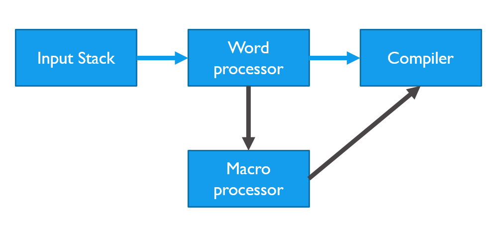

## End of slides (for now)

The rest of this session will follow the SAS program included with today’s materials on Git.

- Start SAS
  - SAS Studio - https://uint.urban.org/sasusers/index.html#sas-studio
- Get session materials from Git https://github.com/UI-Research/AdvancedSAS
  - Click on “intro_to_macros_20190723.sas”
    - Click on “raw” button in top right of code block
    - Copy and paste the SAS code into your SAS environment
  - Download the SAS datasets (demo, hdrs, lns)
  - Other materials:
    - These slides

# Resources

## SAS Sessions

- Combining SAS Macros and PROC SQL
  - Even more automation of dynamic code!
  - Tuesday, August 6th, 12-1pm
  - Same room (Learning and Community Hub, 3030)
  - Email ldurbak@urban.org if you don’t have an invite!
- Using Github on SAS1
  - Version control for SAS programs on SAS1 server (never lose overwritten code again!)
  - Date/time TBD

## SAS Users Group Resources

- SAS Users Group website: https://uint.urban.org/sasusers/index.html (or search “SAS users group” on the intranet)
  - Getting started
  - Bootcamp
  - Brownbags
    - Including this one!
  - UI Guide to SAS
  - Links to SAS Institute Training
  - Git Hub